# DiD1 2x2 Difference-in-Differences

ECON 474 Econometrics of Policy Evaluation

Here we are demonstrating the $2 \times 2$ difference-in-differences. What makes it $2 \times 2$ is that we will be running a regression using a variable for the two groups (treatment and control) and a variable for the two time periods (pre-treatment and post-treatment).

To begin, load in our two favorite packages `tidyverse` and `fixest` along with the data. The data are tiny, so we can also print it.

```r
library(tidyverse)
library(fixest)

banks = read_csv("C:/Users/johnj/Dropbox/Julian/Academia/UIUC/Semester 12 Spring 2023/ECON474sp23/Data/DiD1 Mississippi experiment.csv")
banks
```

```
## # A tibble: 6 × 3
##    year `6th district` `8th district`
##   <dbl>          <dbl>          <dbl>
## 1  1929            141            169
## 2  1930            135            165
## 3  1931            121            132
## 4  1932            113            120
## 5  1933            102            111
## 6  1934            102            109
```

Here we can see that we have data over 6 years. The variables `6th district` and `8th district` are the number of banks operating in each Federal Reserve district. Recall that district 6 is the Atlanta district (treated) and that distrcit 8 is the St. Louis district (control).

# 1 Parallel Trends

Parallel trends means that whatever happens to the control group after treatment is exactly what would have happened to the treatment group if they were not treated. We can hard code this into the data for demonstration purposes of what we require.

To be clear, this **does not provide evidence** that the parallel trends assumption is satisfied. It is only showing what is required for the assumption to be satisfied.

```r
df_plot = banks %>%
  mutate(diff_d8_d6 = `8th district`[year == 1930] - `6th district`[year == 1930],
         counterfactual = if_else(year >= 1930,
                                  `8th district` - diff_d8_d6,
                                  `6th district`)) %>%
  select(-diff_d8_d6) %>%
  pivot_longer(cols = c(`6th district`, `8th district`, counterfactual),
               names_to = 'district',
               values_to = 'n_banks')
```

Now, let’s plot this to see what we the unobservable counterfactual should look like.

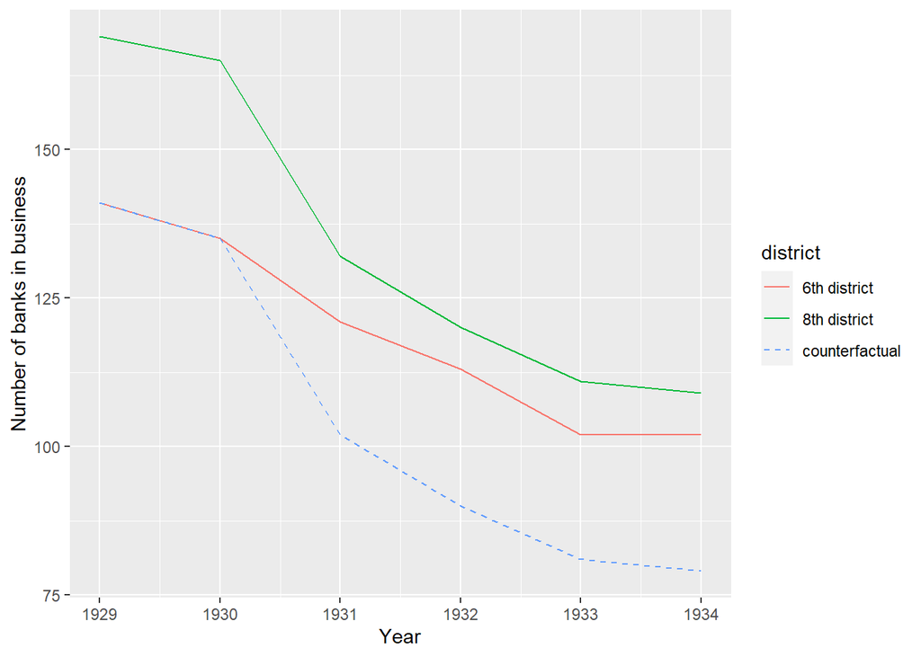

```r
ggplot(df_plot, aes(x = year, y = n_banks, color = district, linetype = district)) +
  geom_line() +
  scale_linetype_manual(values = c(rep("solid", 2), "dashed")) +
  labs(x = "Year", y = "Number of banks in business")
```

# 2 2x2 Difference-in-Differences

To run our first diff-in-diff, we need to take the `df_plot` and remove the made-up counterfactual outcome. When creating a new object, we will also create the two variables that we need to run the regression: `treat` and `post`, which are self-explanatory.

```r
df_reg = df_plot %>%
  filter(district != "counterfactual") %>%
  mutate(treat = (district == '6th district')*1,
         post = (year > 1930)*1)
df_reg
```

```
## # A tibble: 12 × 5
##     year district     n_banks treat  post
##    <dbl> <chr>          <dbl> <dbl> <dbl>
##  1  1929 6th district     141     1     0
##  2  1929 8th district     169     0     0
##  3  1930 6th district     135     1     0
##  4  1930 8th district     165     0     0
##  5  1931 6th district     121     1     1
##  6  1931 8th district     132     0     1
##  7  1932 6th district     113     1     1
##  8  1932 8th district     120     0     1
##  9  1933 6th district     102     1     1
## 10  1933 8th district     111     0     1
## 11  1934 6th district     102     1     1
## 12  1934 8th district     109     0     1
```

Time to run the 2x2 regression! But first, since we have multiple pre-treatment observations and multiple post-treatment observations for each unit, we need to include fixed effects. However, I want to show you how to run a standard diff-in-diff, so we will estimate one regression without fixed effects and another with. Take a look at which coefficients are reported for the second regression. Is this a problem?

```r
fit1 = feols(n_banks ~ treat*post, data = df_reg)
fit2 = feols(n_banks ~ treat*post | district, data = df_reg)
```

```
## The variable 'treat' has been removed because of collinearity (see $collin.var).
```

```r
etable(fit1, fit2,
       se.below = TRUE)
```

```
##                      fit1        fit2
## Dependent Var.:   n_banks     n_banks
##
## Constant        167.0***
##                  (6.190)
## treat           -29.00*
##                  (8.754)
## post            -49.00*** -49.00***
##                  (7.581)   (1.72e-14)
## treat x post     20.50     20.50***
##                 (10.72)    (2.19e-14)
## Fixed-Effects:  --------- -----------
## district               No         Yes
## _______________ _________ ___________
## S.E. type             IID by: distr..
## Observations           12          12
## R2                0.89059     0.89059
## Within R2              --     0.87483
## ---
## Signif. codes: 0 '***' 0.001 '**' 0.01 '*' 0.05 '.' 0.1 ' ' 1
```

To conclude, I want to show you visually what these regressions are actually estimating. The short answer is averages. Try to think about how the plotted averages map into the potential outcomes framework.

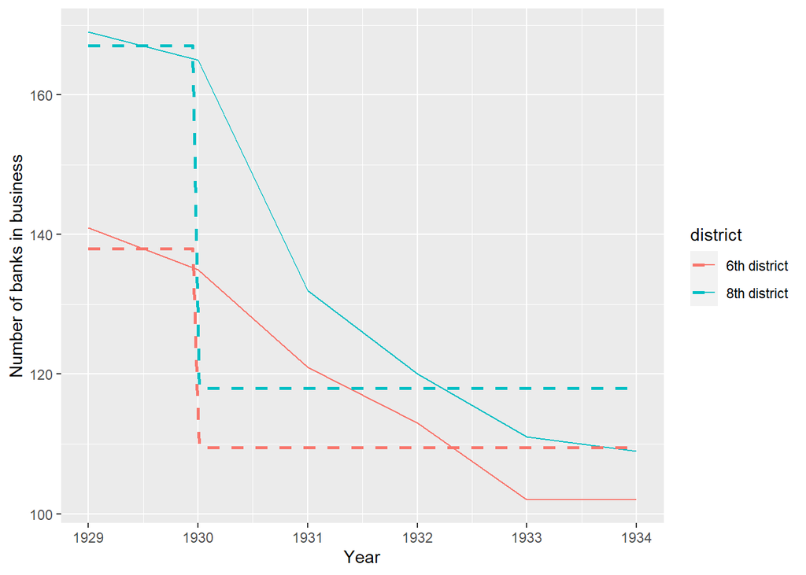

```r
ggplot(df_reg, aes(x = year, y = n_banks, color = district)) +
  geom_line() +
  labs(x = "Year", y = "Number of banks in business") +
  geom_smooth(method = "lm",
              formula = y ~ I(x > 1930),
              se = FALSE,
              linetype = 'dashed')
```